# Graph Exploration and Brief

Ajinkya Shinde

14th May 2018

### 1. Relevant R-Code

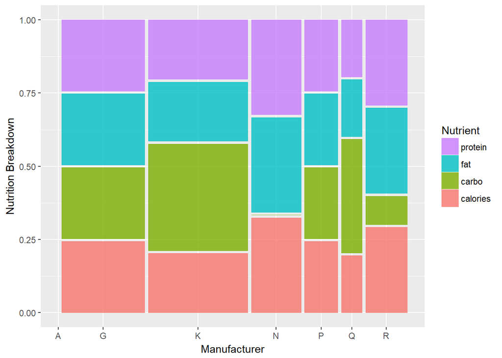

```r
cereal_untidy<-read.csv(file="data/cereal.csv")

cereal_tidy<-cereal_untidy %>%
  gather(nutrition,nutr_stat,c("calories","protein","fat","sodium","fiber","carbo","sugars","potass","vitamins")) %>%
  select(name,mfr,type,nutrition,nutr_stat) %>%
  filter(nutrition==c("calories","protein","fat","carbo"))


ggplot(cereal_tidy)+geom_mosaic(aes(x=product(nutrition,mfr),fill=factor(nutrition))) +
  labs(x="Manufacturer", y ="Nutrition Breakdown") +
  guides(fill=guide_legend(title = "Nutrient", reverse = TRUE))
```

### 2. Description of the TYPE of graph

This type of graph is a Marimekko chart

### 3. Description of the DATA you used

The data is gathered from [Kaggle Dataset](https://www.kaggle.com/crawford/80-cereals/data).It gives the nutrient information(such as calories,fat,protein etc.) for all the cereals across selected 7 brands.The quantitative varaibles such as calories,fat,protien etc are stored in individual column. The quantitative varaibles are name,manufacture name,type of cereal i.e hot/cold in individual columns.

### 3. Representation Description: WHAT ARE YOU TRYING TO SHOW! Tell us about the graph, what it shows, how it can be used, definitions of different graph parts, etc.

The chart shows the distribution of the selected nutrients information such as calories and nutrient breakup across different manufacturer.

### 4. How to read it & What to look for: How should a newbie to this graph approach interpreting it? What are the major highlights of the graph type?

For a newbie, he should make a rough observation about the number of products available across different manufacturer looking at the width and get a glance of nutrient distribution.

**Major Highlights of the graph type**

After observation,it seems like product N offers more protein as compared to other products such as P,Q. Also, the width of the columns indicate the no. of products available such as manufacturer K has lot of products in the data set.

### 5. Presentation tips: address how annotation is/can be used, how color is/can be used, and how the general composition is arranged (how are things arranged, scale, etc.)

Annotation can be used to represent the relative % such that the % distribution also takes into consideration the width variable.The color can be improved using categorical color scheme since the chart is with default color scheme

### 6. Variations and alternatives: are there common variations of this graph? How are they different, how are they used? Are there alternatives?

The common variations of this chart can be Treemap,Radial column chart which displays breakup of individual categorical variables and the same time allows to compare individual breakups with others.

### 7. How I created it: Methods section. How did you go about making this specific graph?

The dataset is in the untidy form which was tidied such that all the nutrient measurables are stored in `nutr_stat` column using `tidyr` package.After tidying the dataset,I began to evaluate different quantitative variables and how can I analyze them.Then,I listed the possible graphs available aligned with the chart I wanted.Earlier, I used stacked bar chart but it was not able to encode `nutr_stats` column for y aesthetic. Then I settled for Marimekko chart.